# Used Car Price Prediction

## Solution

### Setup

To predict `price` from other given variables, first load relevant libraries and dataset for modelling with Random Forest.

```r
# Load relevant libraries and data
library(tidyverse)
library(car) # Anova(.)
library(randomForest) #randomforest(.)
library(caret)

vehicles <- read.csv("vehicles.csv", na.strings=c("NA", "NaN", ""))
```

Before start using the dataset, some data cleaning is needed.

```r
# Remove irrelevant columns and rows that with NA
dfRaw <- na.omit(select(vehicles, -url, -region_url, -VIN, -image_url, -description,
                        -county, -lat, -long, -posting_date))
# Filter out rows with extreme high / low price
dfRaw <- dfRaw %>% filter(price > 999, price < 100000)
# Set covariate "year" as factor
dfRaw$year <- as.factor(dfRaw$year)

# Use systematic sampling method to get a subset of the dataset for a faster run of model
df <- dfRaw %>% filter(row_number() %% 10 == 1)
head(df)
```

```
##           id     region price year manufacturer      model condition
## 1 7316356412     auburn 15000 2013         ford  f-150 xlt excellent
## 2 7316868220 birmingham 10950 2009        lexus      rx350 excellent
## 3 7316031977 birmingham 45000 2017    chevrolet  silverado excellent
## 4 7315259946 birmingham 98900 2001      ferrari 360 modena      good
## 5 7314833347 birmingham  4000 2002       toyota      camry  like new
## 6 7314334186 birmingham  6950 2011   volkswagen      jetta excellent
##     cylinders fuel odometer title_status transmission drive      size
## 1 6 cylinders  gas   128000        clean    automatic   rwd full-size
## 2 6 cylinders  gas   191955        clean    automatic   4wd full-size
## 3 8 cylinders  gas    92000        clean    automatic   4wd full-size
## 4 8 cylinders  gas    20187        clean    automatic   rwd  mid-size
## 5 4 cylinders  gas   160000        clean    automatic   fwd full-size
## 6 5 cylinders  gas   116000        clean    automatic   fwd full-size
##          type paint_color state
## 1       truck       black    al
## 2         SUV       white    al
## 3       truck         red    al
## 4 convertible         red    al
## 5       sedan       white    al
## 6       sedan      silver    al
```

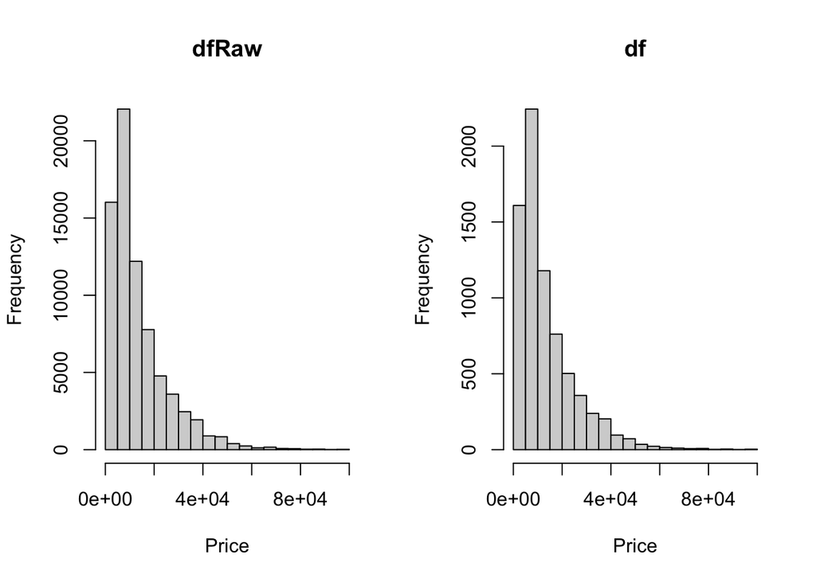

```r
# Compare the price distribution for the original dataset and its subset
par(mfrow=c(1, 2)); hist(dfRaw$price, main = "dfRaw", xlab = "Price")
hist(df$price, breaks = 20,  main = "df", xlab = "Price"); par(mfrow=c(1, 1))
```

As the two distributions looks similar, the subset is trustworthy and be used for modelling.

### Exploratory Data Analysis

Fitting simple linear model to pick 4 most important covariates for modelling with Random Forest.

```r
# Fitting simple linear model with all covariates (dropping off those with large df)
lm <- lm(price ~ . -region -year -model, data = df)
Anova(lm)
```

```
## Anova Table (Type II tests)
##
## Response: price
##                  Sum Sq   Df  F value    Pr(>F)
## id           8.5642e+08    1  10.9968 0.0009172 ***
## manufacturer 2.3701e+10   40   7.6083 < 2.2e-16 ***
## condition    6.8811e+10    5 176.7126 < 2.2e-16 ***
## cylinders    4.4352e+09    7   8.1357 6.714e-10 ***
## fuel         4.8408e+10    4 155.3954 < 2.2e-16 ***
## odometer     2.7980e+10    1 359.2758 < 2.2e-16 ***
## title_status 2.8971e+09    5   7.4401 5.686e-07 ***
## transmission 7.4234e+07    2   0.4766 0.6209115
## drive        1.2501e+10    2  80.2567 < 2.2e-16 ***
## size         1.3698e+09    3   5.8629 0.0005398 ***
## type         2.3365e+10   12  25.0014 < 2.2e-16 ***
## paint_color  1.0545e+10   11  12.3094 < 2.2e-16 ***
## state        1.7612e+10   50   4.5228 < 2.2e-16 ***
## Residuals    5.6260e+11 7224
## ---
## Signif. codes:  0 '***' 0.001 '**' 0.01 '*' 0.05 '.' 0.1 ' ' 1
```

Pick the 4 most important covariates based on the least *p*-values. Here, `condition`, `fuel`, `odometer`, `drive` will be used for the following modelling.

### Random Forest

Prepare a training data and a test data (80/20 split) from the dataset, then modelling the data with Random Forest. Start with fewer trees using `ntree = 25`. Test for the possible no. of variables randomly sampled as candidates at each split, i.e. `mtry = 3`, `mtry = 2` and `mtry = 1`, and also try on using all selected covariates, i.e. Bagging - `mtry = 4`.

```r
set.seed(5986)
# Separate out training and test data (80/20 split)
trainIndex <- sample(1:nrow(df), round(nrow(df)*0.8))
testResponse <- df[-trainIndex, "price"]

# Start with fewer trees, and randomly sample m (with m < p) covariates as splitting candidates
vehiclesRF = list(); predict = list(); mse = list()
for(i in 1:4) {
  rf <- randomForest(price ~ condition + fuel + odometer + drive, data = df, subset = trainIndex,
                     mtry = i, ntree = 25)
  vehiclesRF[[length(vehiclesRF) + 1]] <- rf

  # Predict to the test data
  pred <- predict(vehiclesRF[i], newdata = df[-trainIndex, ])
  predict[[length(predict) + 1]] <- pred
  # Test MSE
  testMSE <- mean((unlist(predict[i]) - testResponse)^2)
  mse[[length(mse) + 1]] <- c("mtry", i, testMSE)
}
mse
```

```
## [[1]]
## [1] "mtry"             "1"                "68743831.3706561"
##
## [[2]]
## [1] "mtry"             "2"                "60921466.9568478"
##
## [[3]]
## [1] "mtry"             "3"                "63514437.8664374"
##
## [[4]]
## [1] "mtry"             "4"                "68504852.8010765"
```

Result shows that the model of Random Forest using `mtry = 2` returns with the lowest MSE.

With sampling the covariates using `mtry = 2`, use out-of-bag (a generalization error) and store the test errors to see the how it changes with increasing the size of trees.

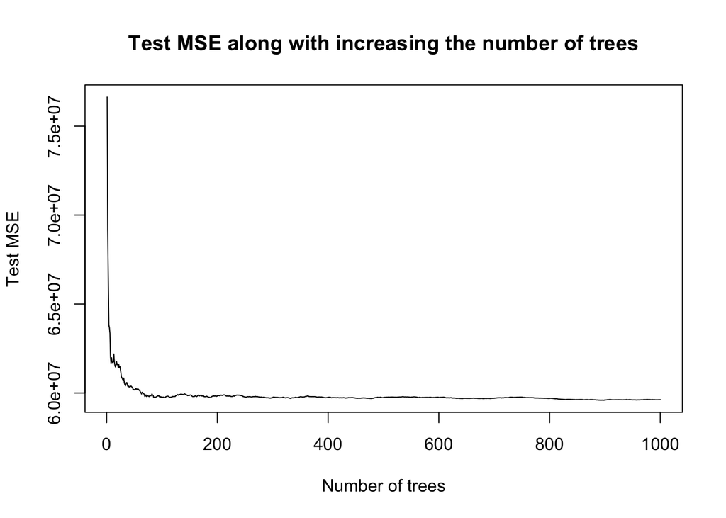

```r
# Use OOB to pass test set in to store test errors as progress
testCov <- df[-trainIndex, ] %>% dplyr::select(-price, -id, -region, -year, -manufacturer, -model, -cylinders,
                                               -title_status, -transmission, -size, -type, -paint_color, -state)
# Try with more trees, say 1,000
vehiclesRF2 <- randomForest (price ~ condition + fuel + odometer + drive, data = df, subset = trainIndex,
                             xtest = testCov, ytest = testResponse, mtry = 2, ntree = 1000)
vehiclesRF2TestError <- vehiclesRF2$test$mse
plot(vehiclesRF2TestError, type = "l", ylab = "Test MSE", xlab = "Number of trees",
     main = "Test MSE along with increasing the number of trees")
```

The graph indicates that should be having around 100 trees for the test error to plateau, here the following will be using 500 trees.

```r
vehiclesRF2 <- randomForest(price ~ condition + fuel + odometer + drive,  data = df, subset = trainIndex,
                            mtry = 2, ntree = 500)
# Predict to the test data
pred <- predict(vehiclesRF2, newdata = df[-trainIndex, ])
head(setNames(data.frame(df[-trainIndex, "id"], df[-trainIndex, "price"], pred), c("id", "price", "prediction")))
```

```
##            id price prediction
## 2  7316868220 10950   9967.264
## 4  7315259946 98900  42926.945
## 7  7313889508 11500  12396.244
## 12 7311505593  1800   3449.779
## 13 7311387137 24990  13929.614
## 28 7305217525  5500   8033.186
```

```r
# test MSE
mean((pred - testResponse)^2)
```

```
## [1] 59514971
```

Result shows that the model performance has been improved, with a better (lower) test error when increasing the size of trees.